# Dropout Prediction: A Systematic Literature Review

This was developed with quanteda version 1.1.1, installation instructions available [here](https://cran.r-project.org/web/packages/quanteda/index.html), [vignetes](https://cran.r-project.org/web/packages/quanteda/vignettes/quickstart.html). The pdfs where readed with [readtext](https://cran.r-project.org/web/packages/readtext/index.html) which suport functions for importing and handling text files and formatted text files with additional-data, such: ‘.csv’, ‘.tab’, ‘.json’, ‘.xml’, ‘.html’, ‘.pdf’, ‘.doc’, ‘.docx’, ‘.rtf’, ‘.xls’, ‘.xlsx’, and others.

```
Benoit, K., Watanabe, K., Wang, H., Nulty, P., Obeng, A., Müller, S., & Matsuo, A. (2018). quanteda: An R package for the quantitative analysis of textual data. Journal of Open Source Software, 3(30), 774. https://doi.org/10.21105/joss.00774
```

Silge & Robinson (2016) developed [tidytext] to make text mining tasks easier, more effective and consistent with tools already in wide use. This package provides commands that allow you to convert text to and from tidy formats. Allow analysis and visualisation: sentiment analysis, tf-idf statistics, n-grams or topic modelling. Best for visualization of the output

We will be using also [revtools](https://cran.r-project.org/web/packages/revtools/index.html) Screening is usually achieved by manually sorting titles or abstracts one at a time. screen_topics offers an alternative by allowing the user to group data by any column in the input dataset, and running a topic model on the resulting data. This allows a great deal of flexibility to locate patterns in journals, years, or authors, rather than just articles.  
Data points can be selected or excluded individually, or by topic.

```r
# get rmarkdown directory
caminho<-getwd()
# set working directory
setwd(caminho)
```

# Import Libraries

```r
# Setup library
library('quanteda')
library('readtext')
library('revtools')
```

# revtools

```r
data_revtools<-read_bibliography("asreview/asreview_result_dropout-prediction-a-systematic-literature-review-v3_FINAL.csv")
data_revtools<- data_revtools[data_revtools$final_included==1,]
#analysis_revtools<-screen_topics(data_revtools)
#analysis_revtools
```

## Creating a document-term matrix for the title

min_freq: minimum proportion of entries that a term must be found in to be retained in the analysis. Defaults to 0.01. We have adjusted to 0.05

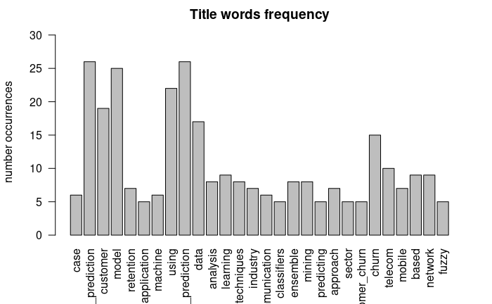

```r
library(lattice)
library(ggplot2)

x_dtm<-make_dtm(data_revtools$title,min_freq = 0.05)

#create a matrix of the document term-matrix
x_dtm_matrix <- as.matrix(x_dtm)
#apply function to calculate columns totals
totals<-apply(x_dtm_matrix,MARGIN = 2,sum)
par(las=2)
barplot(totals,ylim = c(0,max(totals)+5),main = "Title words frequency",ylab = "number occurrences")
```

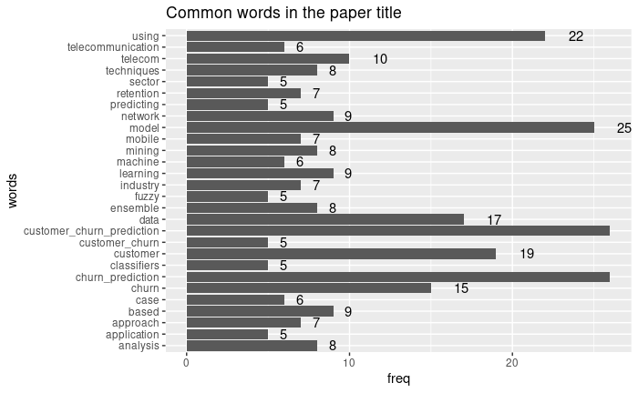

```r
#create dataframe
df_dtm<-data.frame(totals)
df_dtm$words<-row.names(df_dtm)

ggplot(data = df_dtm,aes(x=words,y=totals)) +
  labs(title = "Common words in the paper title",y = "freq")+ #modify legend and plot labels
  geom_bar(stat = "identity") + coord_flip()+
  geom_text(aes(label=totals),hjust=-1.6)
```

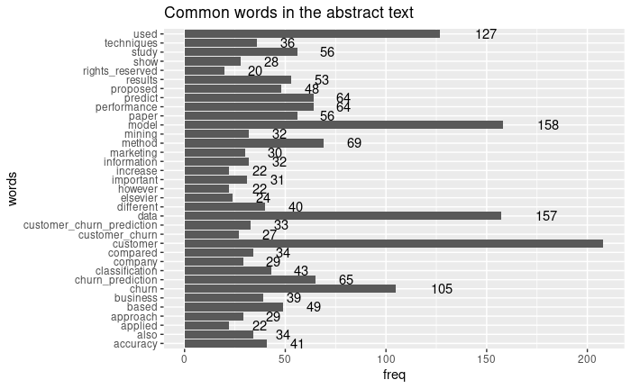

```r
x_dtm<-make_dtm(data_revtools$abstract,min_freq = 0.20)
#create a matrix of the document term-matrix
x_dtm_matrix <- as.matrix(x_dtm)
#apply function to calculate columns totals
totals<-apply(x_dtm_matrix,MARGIN = 2,sum)
#create dataframe
df_dtm<-data.frame(totals)
df_dtm$words<-row.names(df_dtm)

ggplot(data = df_dtm,aes(x=words,y=totals)) +
  labs(title = "Common words in the abstract text",y = "freq")+ #modify legend and plot labels
  geom_bar(stat = "identity") + coord_flip()+
  geom_text(aes(label=totals),hjust=-1.6)
```

```r
NA
NA
```

#Select only select articles

```r
pdf.files  <- list.files(path=caminho,recursive=T,pattern="pdf$",full.names=TRUE)
```

# Reading the PDFs

```r
pdfs<-readtext(pdf.files[1],docvarsfrom = "filenames", sep = "_", docvarnames = c("author", "year","title"))
for (file in pdf.files[2:length(pdf.files)]) {
  pdf<-readtext(file,docvarsfrom = "filenames", sep = "_", docvarnames = c("author", "year","title"))
  pdfs <- rbind(pdfs,pdf)
}
pdfs
```

```
readtext object consisting of 85 documents and 3 docvars.
# Description: df[,5] [85 × 5]
  doc_id                                                  text         author        year title
  <chr>                                                   <chr>        <chr>        <int> <chr>
1 Hung et al_2006_Applying data mining to telecom churn … "\"Associat… Hung et al    2006 Applying data mining to telecom churn m…
2 Dierkes et al_2011_Estimating the effect of word of mo… "\"        … Dierkes et …  2011 Estimating the effect of word of mouth …
3 Liu et al_2020_Micro- and macro-level churn analysis o… "\"        … Liu et al     2020 Micro- and macro-level churn analysis o…
4 Kaya et al_2018_Behavioral attributes and financial ch… "\"Kaya et … Kaya et al    2018 Behavioral attributes and financial chu…
5 Mitrovic et al_2018_On the operational efficiency of d… "\"  On the… Mitrovic et…  2018 On the operational efficiency of differ…
6 Oskarsdottir et al_2018_Profit-Based Model Selection f… "\" Profit … Oskarsdotti…  2018 Profit-Based Model Selection for Custom…
# … with 79 more rows
```

```r
# Transform the journal articles into a corpus object
pdfs_corpus  <- corpus(pdfs)
summary(pdfs_corpus, 5)
```

```
Corpus consisting of 85 documents, showing 5 documents:

                                                                                                  Text Types Tokens Sentences
                                  Hung et al_2006_Applying data mining to telecom churn management.pdf  1607   6424       245
 Dierkes et al_2011_Estimating the effect of word of mouth on churn and cross-buying in the mobile.pdf  2292  12093       586
                  Liu et al_2020_Micro- and macro-level churn analysis of large-scale mobile games.pdf  2537  16527       643
                              Kaya et al_2018_Behavioral attributes and financial churn prediction.pdf  2570  12573       491
      Mitrovic et al_2018_On the operational efficiency of different feature types for telco Churn.pdf  2608  14009       496
         author year                                                                          title
     Hung et al 2006                               Applying data mining to telecom churn management
  Dierkes et al 2011 Estimating the effect of word of mouth on churn and cross-buying in the mobile
      Liu et al 2020              Micro- and macro-level churn analysis of large-scale mobile games
     Kaya et al 2018                           Behavioral attributes and financial churn prediction
 Mitrovic et al 2018       On the operational efficiency of different feature types for telco Churn
```

# Build a document feature matrix

```r
pdfs_corpus  <- corpus(pdfs[1:10,])
corpus_DFM <- dfm(pdfs_corpus, tolower = TRUE, stem = FALSE, remove = c('@',"et", "al", "fig", "table", "ml", "http", stopwords(language = 'en',source = "smart")),
                  remove_punct = TRUE, remove_numbers = TRUE)

dfm_sort(corpus_DFM)
```

```
Document-feature matrix of: 10 documents, 7,830 features (80.0% sparse) and 3 docvars.
                                                                                                           features
docs                                                                                                        data churn customer
  Hung et al_2006_Applying data mining to telecom churn management.pdf                                        67    77       53
  Dierkes et al_2011_Estimating the effect of word of mouth on churn and cross-buying in the mobile.pdf       87   121       70
  Liu et al_2020_Micro- and macro-level churn analysis of large-scale mobile games.pdf                        49   191        3
  Kaya et al_2018_Behavioral attributes and financial churn prediction.pdf                                   140    84       74
  Mitrovic et al_2018_On the operational efficiency of different feature types for telco Churn.pdf            36    26       32
  Oskarsdottir et al_2018_Profit-Based Model Selection for Customer Retention Using Individual Customer.pdf   17    37       83
                                                                                                           features
docs                                                                                                        prediction model
  Hung et al_2006_Applying data mining to telecom churn management.pdf                                              20    62
  Dierkes et al_2011_Estimating the effect of word of mouth on churn and cross-buying in the mobile.pdf             25    36
  Liu et al_2020_Micro- and macro-level churn analysis of large-scale mobile games.pdf                              80    52
  Kaya et al_2018_Behavioral attributes and financial churn prediction.pdf                                          59    21
  Mitrovic et al_2018_On the operational efficiency of different feature types for telco Churn.pdf                  16    23
  Oskarsdottir et al_2018_Profit-Based Model Selection for Customer Retention Using Individual Customer.pdf         18    70
                                                                                                           features
docs                                                                                                        customers performance
  Hung et al_2006_Applying data mining to telecom churn management.pdf                                             32          24
  Dierkes et al_2011_Estimating the effect of word of mouth on churn and cross-buying in the mobile.pdf            55           6
  Liu et al_2020_Micro- and macro-level churn analysis of large-scale mobile games.pdf                              0          26
  Kaya et al_2018_Behavioral attributes and financial churn prediction.pdf                                         72          17
  Mitrovic et al_2018_On the operational efficiency of different feature types for telco Churn.pdf                 13          19
  Oskarsdottir et al_2018_Profit-Based Model Selection for Customer Retention Using Individual Customer.pdf        33          54
                                                                                                           features
docs                                                                                                         = feature models
  Hung et al_2006_Applying data mining to telecom churn management.pdf                                      25       1     22
  Dierkes et al_2011_Estimating the effect of word of mouth on churn and cross-buying in the mobile.pdf     12       1     28
  Liu et al_2020_Micro- and macro-level churn analysis of large-scale mobile games.pdf                      95      28     17
  Kaya et al_2018_Behavioral attributes and financial churn prediction.pdf                                  11      36     31
  Mitrovic et al_2018_On the operational efficiency of different feature types for telco Churn.pdf          23     136      4
  Oskarsdottir et al_2018_Profit-Based Model Selection for Customer Retention Using Individual Customer.pdf 49       3     37
[ reached max_ndoc ... 4 more documents, reached max_nfeat ... 7,820 more features ]
```

```r
stopwords("english")
```

```
  [1] "i"          "me"         "my"         "myself"     "we"         "our"        "ours"       "ourselves"  "you"
 [10] "your"       "yours"      "yourself"   "yourselves" "he"         "him"        "his"        "himself"    "she"
 [19] "her"        "hers"       "herself"    "it"         "its"        "itself"     "they"       "them"       "their"
 [28] "theirs"     "themselves" "what"       "which"      "who"        "whom"       "this"       "that"       "these"
 [37] "those"      "am"         "is"         "are"        "was"        "were"       "be"         "been"       "being"
 [46] "have"       "has"        "had"        "having"     "do"         "does"       "did"        "doing"      "would"
 [55] "should"     "could"      "ought"      "i'm"        "you're"     "he's"       "she's"      "it's"       "we're"
 [64] "they're"    "i've"       "you've"     "we've"      "they've"    "i'd"        "you'd"      "he'd"       "she'd"
 [73] "we'd"       "they'd"     "i'll"       "you'll"     "he'll"      "she'll"     "we'll"      "they'll"    "isn't"
 [82] "aren't"     "wasn't"     "weren't"    "hasn't"     "haven't"    "hadn't"     "doesn't"    "don't"      "didn't"
 [91] "won't"      "wouldn't"   "shan't"     "shouldn't"  "can't"      "cannot"     "couldn't"   "mustn't"    "let's"
[100] "that's"     "who's"      "what's"     "here's"     "there's"    "when's"     "where's"    "why's"      "how's"
[109] "a"          "an"         "the"        "and"        "but"        "if"         "or"         "because"    "as"
[118] "until"      "while"      "of"         "at"         "by"         "for"        "with"       "about"      "against"
[127] "between"    "into"       "through"    "during"     "before"     "after"      "above"      "below"      "to"
[136] "from"       "up"         "down"       "in"         "out"        "on"         "off"        "over"       "under"
[145] "again"      "further"    "then"       "once"       "here"       "there"      "when"       "where"      "why"
[154] "how"        "all"        "any"        "both"       "each"       "few"        "more"       "most"       "other"
[163] "some"       "such"       "no"         "nor"        "not"        "only"       "own"        "same"       "so"
[172] "than"       "too"        "very"       "will"
```

```
min.freqcolorsrandom.orderrot.per is deprecated; use min_countcolorrandom_orderrotation instead
```

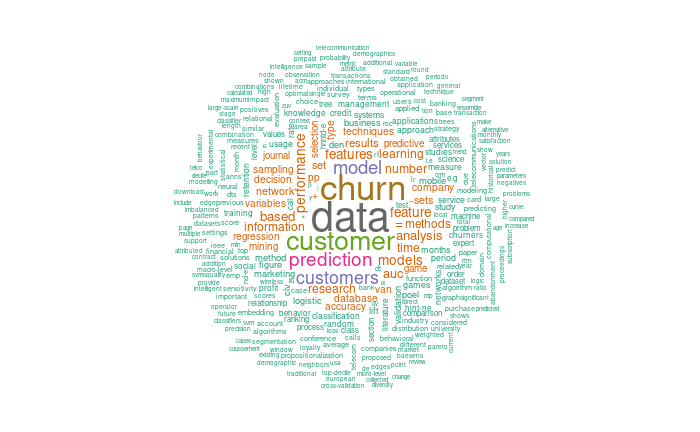

```r
textplot_wordcloud(corpus_DFM, min.freq = 30, random.order=F, rot.per = .10,colors = RColorBrewer::brewer.pal(8,'Dark2'))
```

```r
#summary(corpus_DFM)
topfeatures(corpus_DFM, 100)
```

```
          data          churn       customer     prediction          model      customers    performance              =
          1018            842            616            390            378            357            243            241
       feature         models       features          based       analysis            auc         number       learning
           240            239            238            231            223            215            202            200
      research           time    information        methods        results            set        network           sets
           199            198            196            190            181            165            162            161
    techniques              +       database        company       decision      variables       accuracy             pp
           156            149            145            144            143            141            141            141
      sampling            van           type     regression         mining     predictive           game      selection
           140            140            139            137            136            132            132            130
       journal         method         mobile      marketing       business            clv       logistic         figure
           128            125            124            123            123            120            119            118
          lift     validation            den           poel          games         months          study         period
           118            117            116            115            114            113            109            104
             −        service          usage       approach        measure        systems              ∗      retention
           104            103            103            103            101            100            100             98
classification           rate         credit       networks      knowledge        studies     management   applications
            97             96             95             94             93             93             92             91
        random       training         profit     literature       churners       behavior         social        hlnt-ne
            91             91             89             88             86             85             84             84
       problem         values        machine   relationship        section            e.g          class       services
            81             81             80             79             79             79             78             77
          test        science          level           tree         expert        process           call     attributes
            77             77             76             75             75             74             73             73
    comparison        ranking        dataset          order
            73             73             73             72
```

```r
library(quanteda.textmodels)
tmod_wf <- textmodel_wordfish(corpus_DFM,c(6,5))
summary(tmod_wf)
```

```
Call:
textmodel_wordfish.dfm(x = corpus_DFM, dir = c(6, 5))

Estimated Document Positions:
```

|  | theta | se |
| --- | --- | --- |
| Hung et al_2006_Applying data mining to telecom churn management.pdf | -0.2507548 | 0.024607092 |
| Dierkes et al_2011_Estimating the effect of word of mouth on churn and cross-buying in the mobile.pdf | 0.3085168 | 0.017540171 |
| Liu et al_2020_Micro- and macro-level churn analysis of large-scale mobile games.pdf | 1.5076805 | 0.005848839 |
| Kaya et al_2018_Behavioral attributes and financial churn prediction.pdf | 0.0784885 | 0.017138116 |
| Mitrovic et al_2018_On the operational efficiency of different feature types for telco Churn.pdf | 1.0974019 | 0.010833602 |
| Oskarsdottir et al_2018_Profit-Based Model Selection for Customer Retention Using Individual Customer.pdf | 0.7127829 | 0.016474115 |
| Zhu et al_2018_Benchmarking sampling techniques for imbalance learning in churn prediction.pdf | 0.2831490 | 0.018176826 |
| Garcia et al_2017_Intelligent data analysis approaches to churn as a business problem.pdf | -1.0144164 | 0.009288460 |
| Ballings Van den Poel_2012_Customer event history for churn prediction.pdf | -1.2307287 | 0.016190677 |
| Ballings et al_2012_Improving Customer Churn Prediction by Data Augmentation Using Pictorial.pdf | -1.4921197 | 0.009035813 |

```
Estimated Feature Scores:
     association information systems     ais electronic library   aisel  pacific     asia conference   pacis proceedings december
beta     -1.7466     -0.3902 -0.9337 -0.5899    -0.4507 -0.1264 -0.5899 -0.06554 -0.10361     0.5818 -0.6024      1.3765   -1.552
psi      -0.3103      2.8355  2.0106 -1.3768    -0.2524 -1.0556 -1.3768 -1.06221  0.04084     1.5229 -0.8689      0.4712   -1.598
     applying    data  mining telecom      churn management shin-yuan    hung national chung-cheng university hsiu-yu    wang
beta  -0.2033 -0.9112 -0.5269  -1.067 -0.0002762    -0.8703   -0.4011 -1.2979  -0.6291     -0.5976     0.3209 -0.4011 -0.5597
psi    0.6984  4.3412  2.4506   1.364  4.2773796     1.9549   -1.0574 -0.4019  -0.4055     -1.0909     1.3024 -1.0574  0.7094
      follow additional   works http://aisel.aisnet.org/pacis2004
beta -0.2977   -0.02532  1.7240                           -0.5351
psi  -0.8275    1.30694 -0.3161                           -2.4636
```

# Extract data from PDFs

## Images

```r
pdf.files
```

```
 [1] "/mnt/hgfs/nuvem/Dropbox/doutoramento/tese/SLRDropout/analysis/selected_articles/final_dataset/files/11391/Hung et al_2006_Applying data mining to telecom churn management.pdf"
 [2] "/mnt/hgfs/nuvem/Dropbox/doutoramento/tese/SLRDropout/analysis/selected_articles/final_dataset/files/11393/Dierkes et al_2011_Estimating the effect of word of mouth on churn and cross-buying in the mobile.pdf"
 [3] "/mnt/hgfs/nuvem/Dropbox/doutoramento/tese/SLRDropout/analysis/selected_articles/final_dataset/files/11397/Liu et al_2020_Micro- and macro-level churn analysis of large-scale mobile games.pdf"
 [4] "/mnt/hgfs/nuvem/Dropbox/doutoramento/tese/SLRDropout/analysis/selected_articles/final_dataset/files/11402/Kaya et al_2018_Behavioral attributes and financial churn prediction.pdf"
 [5] "/mnt/hgfs/nuvem/Dropbox/doutoramento/tese/SLRDropout/analysis/selected_articles/final_dataset/files/11406/Mitrovic et al_2018_On the operational efficiency of different feature types for telco Churn.pdf"
 [6] "/mnt/hgfs/nuvem/Dropbox/doutoramento/tese/SLRDropout/analysis/selected_articles/final_dataset/files/11408/Oskarsdottir et al_2018_Profit-Based Model Selection for Customer Retention Using Individual Customer.pdf"
 [7] "/mnt/hgfs/nuvem/Dropbox/doutoramento/tese/SLRDropout/analysis/selected_articles/final_dataset/files/11411/Zhu et al_2018_Benchmarking sampling techniques for imbalance learning in churn prediction.pdf"
 [8] "/mnt/hgfs/nuvem/Dropbox/doutoramento/tese/SLRDropout/analysis/selected_articles/final_dataset/files/11415/Garcia et al_2017_Intelligent data analysis approaches to churn as a business problem.pdf"
 [9] "/mnt/hgfs/nuvem/Dropbox/doutoramento/tese/SLRDropout/analysis/selected_articles/final_dataset/files/11432/Ballings Van den Poel_2012_Customer event history for churn prediction.pdf"
[10] "/mnt/hgfs/nuvem/Dropbox/doutoramento/tese/SLRDropout/analysis/selected_articles/final_dataset/files/11440/Ballings et al_2012_Improving Customer Churn Prediction by Data Augmentation Using Pictorial.pdf"
[11] "/mnt/hgfs/nuvem/Dropbox/doutoramento/tese/SLRDropout/analysis/selected_articles/final_dataset/files/11453/Burez Van den Poel_2009_Handling class imbalance in customer churn prediction.pdf"
[12] "/mnt/hgfs/nuvem/Dropbox/doutoramento/tese/SLRDropout/analysis/selected_articles/final_dataset/files/11456/Burez Vandenpoel_2008_Separating financial from commercial customer churn.pdf"
[13] "/mnt/hgfs/nuvem/Dropbox/doutoramento/tese/SLRDropout/analysis/selected_articles/final_dataset/files/11459/Burez Van den Poel_2007_CRM at a pay-TV company.pdf"
[14] "/mnt/hgfs/nuvem/Dropbox/doutoramento/tese/SLRDropout/analysis/selected_articles/final_dataset/files/11461/Wai-Ho Au et al_2003_A novel evolutionary data mining algorithm with applications to churn prediction.pdf"
[15] "/mnt/hgfs/nuvem/Dropbox/doutoramento/tese/SLRDropout/analysis/selected_articles/final_dataset/files/11467/De Bock Van den Poel_2010_Ensembles of Probability Estimation Trees for Customer Churn Prediction.pdf"
```

[output cut: 70 more lines]

```r
for(image in pdf.files) {

}
#imageFiles <-PDF_extractImages(pdf.files[2])
```

## Tables

Creating a list of lists. Lists are indexed with double brackets.

```r
library("tabulizer")
library(utils)

pb = txtProgressBar(min = 0, max = length(pdf.files), initial = 0,)
tab = list()
for (i in 1:length(pdf.files)){
  setTxtProgressBar(pb,i)
  try(
    tab[[i]]<-extract_tables(pdf.files[i]),
    silent = TRUE
    )
}
```

### Identifying elements

Perceber quais são os artigos que abordam isto…. tentar fazer um quadro global Por exemplo x artigos abordam AUC, sensitivy…. blá… blá…

Estão exemplos no Edge AOC

```r
# Where is AUC
grep("AUC",tab)
```

```
 [1]  6  7  8 10 23 27 29 32 38 42 44 47 48 49 51 56 60 61 62 63 64 66 67
```

```r
grep("AUC",tab[[6]][[4]])
```

```
[1] 56
```

PDF Scraping in R with tabulizer: 1. https://www.r-bloggers.com/2019/09/pdf-scraping-in-r-with-tabulizer/ 2. https://www.charlesbordet.com/en/extract-pdf/#extract-the-right-information 3. https://www.r-bloggers.com/2018/01/how-to-extract-data-from-a-pdf-file-with-r/ 4. https://github.com/ropensci/tabulizer 5. https://datascienceplus.com/extracting-tables-from-pdfs-in-r-using-the-tabulizer-package/

```r
tab[[6]][[4]]
```

```
      [,1]      [,2]     [,3]        [,4]        [,5]                      [,6]            [,7]
 [1,] ""        ""       ""          ""          "Measure"                 ""              ""
 [2,] "Dataset" "Method" "AUC"       "H-measure" "Top decile lift EMP"     "Mean EMPβ′"    "Median EMPβ′"
 [3,] ""        "LR"     "0.75"      "0.22"      "1.29 306.63"             "281.98"        "172.57"
 [4,] ""        "DT"     "0.82"      "0.36"      "1.47 306.60"             "288.96"        "172.22"
 [5,] "D1"      "RF XGB" "0.85 0.85" "0.41 0.41" "1.46 1.51 306.79 306.81" "282.77 283.42" "170.95168.68"
 [6,] ""        "NN"     "0.86"      "0.44"      "1.53 306.63"             "293.89"        "171.55"
 [7,] ""        "SVM"    "0.83"      "0.38"      "1.51 306.59"             "297.29"        "171.58"
 [8,] ""        "LR"     "0.71"      "0.21"      "1.86 224.25"             "213.57"        "124.91"
 [9,] ""        "DT"     "0.72"      "0.26"      "2.13 224.24"             "203.94"        "124.02"
[10,] "D2"      "RF XGB" "0.75 0.82" "0.30 0.38" "2.07 2.87 224.26 224.56" "203.87 208.62" "124.35123.94"
[11,] ""        "NN"     "0.73"      "0.23"      "1.98 224.13"             "203.30"        "123.00"
[12,] ""        "SVM"    "0.72"      "0.23"      "2.14 224.17"             "208.99"        "123.45"
[13,] ""        "LR"     "0.58"      "0.03"      "1.04 389.32"             "355.01"        "220.35"
[14,] ""        "DT"     "0.62"      "0.05"      "1.05 389.32"             "354.15"        "220.07"
[15,] "D3"      "RF XGB" "0.64 0.64" "0.07 0.07" "1.05 1.04 389.32 389.32" "365.49 356.80" "219.67218.81"
[16,] ""        "NN"     "0.63"      "0.06"      "1.03 389.32"             "365.11"        "219.39"
[17,] ""        "SVM"    "0.58"      "0.03"      "1.05 389.32"             "357.10"        "218.30"
[18,] ""        "LR"     "0.69"      "0.16"      "1.26 171.54"             "157.41"        "92.93"
[19,] ""        "DT"     "0.90"      "0.55"      "2.86 173.46"             "158.28"        "95.06"
[20,] "D4"      "RF XGB" "0.92 0.95" "0.58 0.66" "2.14 3.39 174.37 174.50" "158.78 159.24" "96.1996.10"
[21,] ""        "NN"     "0.85"      "0.43"      "2.55 173.00"             "161.57"        "95.51"
[22,] ""        "SVM"    "0.80"      "0.37"      "2.02 171.52"             "165.27"        "94.60"
[23,] ""        "LR"     "0.84"      "0.40"      "2.29 98.10"              "90.95"         "53.03"
[24,] ""        "DT"     "0.88"      "0.64"      "5.04 97.65"              "89.66"         "51.99"
[25,] "D5"      "RF XGB" "0.91 0.93" "0.71 0.75" "3.05 5.77 97.90 98.54"   "89.44 92.41"   "52.6753.04"
[26,] ""        "NN"     "0.75"      "0.26"      "2.52 97.54"              "90.05"         "51.08"
[27,] ""        "SVM"    "0.87"      "0.48"      "3.16 97.98"              "91.89"         "53.25"
```

```r
# table headers get extracted as rows with bad formatting. Dump them.
final <- as.data.frame(tab[[6]][[4]])
final
```

| V1 | V2 | V3 | V4 | V5 | V6 | V7 |
| --- | --- | --- | --- | --- | --- | --- |
|  |  |  |  | Measure |  |  |
| Dataset | Method | AUC | H-measure | Top decile lift EMP | Mean EMPβ′ | Median EMPβ′ |
|  | LR | 0.75 | 0.22 | 1.29 306.63 | 281.98 | 172.57 |
|  | DT | 0.82 | 0.36 | 1.47 306.60 | 288.96 | 172.22 |
| D1 | RF XGB | 0.85 0.85 | 0.41 0.41 | 1.46 1.51 306.79 306.81 | 282.77 283.42 | 170.95168.68 |
|  | NN | 0.86 | 0.44 | 1.53 306.63 | 293.89 | 171.55 |
|  | SVM | 0.83 | 0.38 | 1.51 306.59 | 297.29 | 171.58 |
|  | LR | 0.71 | 0.21 | 1.86 224.25 | 213.57 | 124.91 |
|  | DT | 0.72 | 0.26 | 2.13 224.24 | 203.94 | 124.02 |
| D2 | RF XGB | 0.75 0.82 | 0.30 0.38 | 2.07 2.87 224.26 224.56 | 203.87 208.62 | 124.35123.94 |

[output cut: 17 more lines]

```r
# Column names
headers <- c('Dataset', 'Method', 'AUC', 'H-measure', 'Measure','Mean EMP', 'Median EMP')

# Apply custom column names
names(final) <- headers
final
```

| Dataset | Method | AUC | H-measure | Measure | Mean EMP | Median EMP |
| --- | --- | --- | --- | --- | --- | --- |
|  |  |  |  | Measure |  |  |
| Dataset | Method | AUC | H-measure | Top decile lift EMP | Mean EMPβ′ | Median EMPβ′ |
|  | LR | 0.75 | 0.22 | 1.29 306.63 | 281.98 | 172.57 |
|  | DT | 0.82 | 0.36 | 1.47 306.60 | 288.96 | 172.22 |
| D1 | RF XGB | 0.85 0.85 | 0.41 0.41 | 1.46 1.51 306.79 306.81 | 282.77 283.42 | 170.95168.68 |
|  | NN | 0.86 | 0.44 | 1.53 306.63 | 293.89 | 171.55 |
|  | SVM | 0.83 | 0.38 | 1.51 306.59 | 297.29 | 171.58 |
|  | LR | 0.71 | 0.21 | 1.86 224.25 | 213.57 | 124.91 |
|  | DT | 0.72 | 0.26 | 2.13 224.24 | 203.94 | 124.02 |
| D2 | RF XGB | 0.75 0.82 | 0.30 0.38 | 2.07 2.87 224.26 224.56 | 203.87 208.62 | 124.35123.94 |

[output cut: 17 more lines]

```r
NA
```

```r
library(writexl)
write_xlsx(as.data.frame(tab),path = 'tables.xlsx')
```

```
Error in (function (..., row.names = NULL, check.rows = FALSE, check.names = TRUE,  :
  arguments imply differing number of rows: 16, 2, 5, 6, 10, 7, 4, 11
```